# Project-1, ST558

Pratap Adhikari

9/18/2020

```r
knitr::opts_chunk$set(echo = TRUE, cache=T, message=F, warning=F)
```

```r
library(knitr)
library(httr)
library(jsonlite)
library(tidyverse)
library(dplyr)
library(haven)
library(ggplot2)
#install.packages("qwraps2")
library(qwraps2)
library(rmarkdown)
library(RSQLite)
```

## Project1-ST558

### List of library packages

The list of library packages I have used to run this code in order to carry on this project are:

- knitr
- httr
- jsonlite
- tidyverse
- dplyr
- haven
- ggplot2
- qwraps2
- rmarkdown
- RSQlite

### Function to get franchiseAPI

```r
nhl<- function(tabName, ID=NULL, ...){
  base_url<- "https://records.nhl.com/site/api"
  if (!is.null(tabName)){

     if ( tabName %in% c("franchise", "franchise-team-totals") && (!is.null(ID))){
    stop("This tab can not return with 'ID' defined")
  }

    if (is.null(ID)){
    full_url<- paste0(base_url, "/", tabName)
  }

    if (!is.null(ID)){
     full_url<- paste0(base_url, "/", tabName, ID)
  }
  get_nfl<- GET(full_url)
  txt_nfl<- content(get_nfl, "text")  # convert to JSON text form
  json_nfl<- fromJSON(txt_nfl, flatten=T) # convert to list
return(json_nfl)
  }
  else {
    return("Invalid tabName")
  }
}
```

### Function to get statsAPI

```r
nhl_modifier<- function(modifier, ID=NULL,...){
  stbase_url<- "https://statsapi.web.nhl.com/api/v1/teams"
  if (modifier %in%  c("expand=team.roster", "expand=person.names", "expand=team.schedule.next", "expand=team.schedule.previous",  "expand=team.stats",  "expand=team.roster&season=20142015", "teamId=4,5,29",  "stats=statsSingleSeasonPlayoffs"))
  {
    get_st<- GET(paste0(stbase_url, "?", modifier))
st_txt<- content(get_st, "text")
json_st<- fromJSON(st_txt, flatten=T)

}
else {
  json_st="Sorry, can't accept this modifier"

}
return(json_st)
}
```

```r
nhlData<- function (tabName=NULL, modifier=NULL, ID=NULL, ...){
if (!is.null(tabName) && !is.null(modifier)){
  stop("it can not work together with tabName and modifier")

}
if(is.null(tabName) && is.null(modifier) ){

  output<- nhl("franchise")
}
  if (is.null(modifier) && !is.null(tabName)){
     output<- nhl(tabName, ID)
     output<- output$data
  }
  # if modifier is not null and id is null
  if(!is.null(modifier) && is.null(id)){
   output<- nhl_modifier(modifier)
  }

  #if both modifier and id are not  null
  if(!is.null(modifier) && !is.null(id) ){
    output<- nhl_modifier(modifier)
    output<- output$teams
    output<- output %>% filter(id==ID) %>% select(id:roster.link)

  }
  return(output)
}
```

### Overview of franchise and location

```r
#teamtotal<- nhl(tabName = "franchise-team-totals")$data

#getteams from another endpoint

#division<- nhl_modifier(modifier = "expand=team.roster")$teams %>% select(id, division.name,  locationName, division.nameShort, conference.name) %>% rename(teamId=id)
#join the two dataset from two different APIs

#newData<- left_join(teamtotal, division, by="teamId")
#head(newData, n=4)
```

```r
# overview of after joining two datasets from two different API endpoints
#kable(newData %>% select(id, franchiseId, teamName, locationName) , caption= "Franchise ID, Team Name, Location  table for your reference:")
```

```r
dta1<- nhlData("franchise")
dta1<- dta1 %>% select(id, mostRecentTeamId, teamCommonName, teamPlaceName)

golietable15<- nhl(tabName  = "franchise-goalie-records?cayenneExp=franchiseId=", ID=15)$data %>% select(activePlayer, firstName, franchiseName, gamesPlayed, lastName, gameTypeId, playerId, mostGoalsAgainstOneGame, ties, wins, losses )
```

### Analysis on team ID=15 (Dallas Stars)

```r
#Create new variable by adding first and last name from two different columns

golietable15$playerName<- c(paste0(golietable15$firstName, " ", golietable15$lastName))

#select only the varaibles required to analyse the data
golietable15<- golietable15 %>% select(franchiseName, playerName, playerId, activePlayer, gameTypeId, gamesPlayed, mostGoalsAgainstOneGame, ties, wins, losses)
golietable15
```

|  | franchiseName | playerName | playerId | activePlayer | gameTypeId | gamesPlayed | mostGoalsAgainstOneGame | ties | wins | losses |
| --- | --- | --- | --- | --- | --- | --- | --- | --- | --- | --- |
| 1 | Dallas Stars | Don Beaupre | 8445381 | FALSE | 2 | 315 | 10 | 45 | 126 | 125 |
| 2 | Dallas Stars | Cesare Maniago | 8450020 | FALSE | 2 | 420 | 10 | 70 | 145 | 190 |
| 3 | Dallas Stars | Marty Turco | 8460612 | FALSE | 2 | 509 | 6 | 26 | 262 | 154 |
| 4 | Dallas Stars | Kari Lehtonen | 8470140 | FALSE | 2 | 445 | 7 | 0 | 216 | 150 |
| 5 | Dallas Stars | Ed Belfour | 8445386 | FALSE | 2 | 307 | 8 | 44 | 160 | 95 |
| 6 | Dallas Stars | Allan Bester | 8445458 | FALSE | 2 | 10 | 5 | 1 | 4 | 5 |
| 7 | Dallas Stars | Daniel Berthiaume | 8445462 | FALSE | 2 | 5 | 4 | 0 | 1 | 3 |
| 8 | Dallas Stars | Gary Edwards | 8446602 | FALSE | 2 | 51 | 8 | 15 | 15 | 18 |
| 9 | Dallas Stars | Brian Hayward | 8447701 | FALSE | 2 | 26 | 6 | 3 | 6 | 15 |
| 10 | Dallas Stars | Jean Levasseur | 8448807 | FALSE | 2 | 1 | 7 | 0 | 0 | 1 |

[output cut: 27 more lines]

#### Categorical Summary

Table showing active players from the **Dallas** team

```r
 table (golietable15  %>% group_by(activePlayer)%>% select(franchiseName, activePlayer))
```

```
##               activePlayer
## franchiseName  FALSE TRUE
##   Dallas Stars    34    3
```

#### Contingency table

```r
# Max goals against one game
kable( table(golietable15 %>% group_by(mostGoalsAgainstOneGame) %>% select(mostGoalsAgainstOneGame, playerName)))
```

|  | Alex Auld | Allan Bester | Anders Lindback | Andrew Raycroft | Andy Moog | Anton Khudobin | Antti Niemi | Arturs Irbe | Ben Bishop | Brent Krahn | Brian Hayward | Cesare Maniago | Corey Hirsch | Cristopher Nilstorp | Daniel Berthiaume | Darcy Wakaluk | Don Beaupre | Ed Belfour | Gary Edwards | Gary Smith | Gilles Meloche | Gump Worsley | Jean Levasseur | Jhonas Enroth | Johan Hedberg | Johan Holmqvist | Jussi Rynnas | Kari Lehtonen | Lindsay Middlebrook | … |
| --- | --- | --- | --- | --- | --- | --- | --- | --- | --- | --- | --- | --- | --- | --- | --- | --- | --- | --- | --- | --- | --- | --- | --- | --- | --- | --- | --- | --- | --- | --- |
| 3 | 0 | 0 | 0 | 0 | 0 | 0 | 0 | 0 | 0 | 1 | 0 | 0 | 0 | 0 | 0 | 0 | 0 | 0 | 0 | 0 | 0 | 0 | 0 | 0 | 0 | 1 | 0 | 0 | 1 | … |
| 4 | 0 | 0 | 0 | 0 | 0 | 0 | 0 | 0 | 0 | 0 | 0 | 0 | 1 | 0 | 1 | 0 | 0 | 0 | 0 | 0 | 0 | 0 | 0 | 0 | 0 | 0 | 0 | 0 | 0 | … |
| 5 | 1 | 1 | 0 | 0 | 0 | 0 | 0 | 0 | 0 | 0 | 0 | 0 | 0 | 1 | 0 | 0 | 0 | 0 | 0 | 0 | 0 | 0 | 0 | 0 | 0 | 0 | 1 | 0 | 0 | … |
| 6 | 0 | 0 | 1 | 0 | 0 | 1 | 1 | 1 | 1 | 0 | 1 | 0 | 0 | 0 | 0 | 0 | 0 | 0 | 0 | 0 | 0 | 0 | 0 | 1 | 1 | 0 | 0 | 0 | 0 | … |
| 7 | 0 | 0 | 0 | 1 | 0 | 0 | 0 | 0 | 0 | 0 | 0 | 0 | 0 | 0 | 0 | 0 | 0 | 0 | 0 | 0 | 0 | 1 | 1 | 0 | 0 | 0 | 0 | 1 | 0 | … |
| 8 | 0 | 0 | 0 | 0 | 0 | 0 | 0 | 0 | 0 | 0 | 0 | 0 | 0 | 0 | 0 | 1 | 0 | 1 | 1 | 0 | 1 | 0 | 0 | 0 | 0 | 0 | 0 | 0 | 0 | … |
| 10 | 0 | 0 | 0 | 0 | 1 | 0 | 0 | 0 | 0 | 0 | 0 | 1 | 0 | 0 | 0 | 0 | 1 | 0 | 0 | 1 | 0 | 0 | 0 | 0 | 0 | 0 | 0 | 0 | 0 | … |

#### Win/Loss Rate

```r
#create new variables
wlRate<- golietable15 %>% mutate(tiesRate= round(ties/gamesPlayed, 2), winRate= round(wins/gamesPlayed, 2) , lossRate= round(losses/gamesPlayed,2), MissedClcn= 1-(tiesRate+winRate+lossRate) ) %>% select(playerName, playerId, gameTypeId, gamesPlayed, activePlayer, winRate, lossRate, MissedClcn)
kable(wlRate)
```

| playerName | playerId | gameTypeId | gamesPlayed | activePlayer | winRate | lossRate | MissedClcn |
| --- | --- | --- | --- | --- | --- | --- | --- |
| Don Beaupre | 8445381 | 2 | 315 | FALSE | 0.40 | 0.40 | 0.06 |
| Cesare Maniago | 8450020 | 2 | 420 | FALSE | 0.35 | 0.45 | 0.03 |
| Marty Turco | 8460612 | 2 | 509 | FALSE | 0.51 | 0.30 | 0.14 |
| Kari Lehtonen | 8470140 | 2 | 445 | FALSE | 0.49 | 0.34 | 0.17 |
| Ed Belfour | 8445386 | 2 | 307 | FALSE | 0.52 | 0.31 | 0.03 |
| Allan Bester | 8445458 | 2 | 10 | FALSE | 0.40 | 0.50 | 0.00 |
| Daniel Berthiaume | 8445462 | 2 | 5 | FALSE | 0.20 | 0.60 | 0.20 |
| Gary Edwards | 8446602 | 2 | 51 | FALSE | 0.29 | 0.35 | 0.07 |
| Brian Hayward | 8447701 | 2 | 26 | FALSE | 0.23 | 0.58 | 0.07 |
| Jean Levasseur | 8448807 | 2 | 1 | FALSE | 0.00 | 1.00 | 0.00 |
| Markus Mattsson | 8449291 | 2 | 2 | FALSE | 0.50 | 0.50 | 0.00 |
| Roland Melanson | 8449547 | 2 | 26 | FALSE | 0.27 | 0.42 | 0.12 |
| Gilles Meloche | 8449550 | 2 | 327 | FALSE | 0.43 | 0.36 | 0.05 |
| Lindsay Middlebrook | 8449588 | 2 | 3 | FALSE | 0.00 | 0.00 | 0.33 |
| Andy Moog | 8449681 | 2 | 175 | FALSE | 0.43 | 0.37 | 0.05 |
| Gump Worsley | 8450152 | 2 | 107 | FALSE | 0.36 | 0.35 | 0.07 |
| Gary Smith | 8451528 | 2 | 39 | FALSE | 0.26 | 0.49 | 0.02 |
| Ron Tugnutt | 8451837 | 2 | 42 | FALSE | 0.43 | 0.40 | 0.05 |
| Darcy Wakaluk | 8452248 | 2 | 65 | FALSE | 0.35 | 0.48 | 0.08 |
| Arturs Irbe | 8456692 | 2 | 35 | FALSE | 0.49 | 0.34 | 0.08 |
| Roman Turek | 8458266 | 2 | 55 | FALSE | 0.55 | 0.25 | 0.13 |
| Corey Hirsch | 8458680 | 2 | 2 | FALSE | 0.00 | 0.50 | 0.50 |
| Tim Thomas | 8460703 | 2 | 8 | FALSE | 0.25 | 0.50 | NA |
| Johan Hedberg | 8460704 | 2 | 19 | FALSE | 0.63 | 0.21 | NA |
| Johan Holmqvist | 8466303 | 2 | 2 | FALSE | 0.50 | 0.00 | NA |
| Andrew Raycroft | 8467453 | 2 | 29 | FALSE | 0.34 | 0.45 | NA |
| Alex Auld | 8467913 | 2 | 21 | FALSE | 0.43 | 0.29 | NA |
| Brent Krahn | 8468489 | 2 | 1 | FALSE | 0.00 | 0.00 | NA |
| Mike McKenna | 8470093 | 2 | 2 | FALSE | 0.50 | 0.50 | 0.00 |
| Ben Bishop | 8471750 | 2 | 143 | TRUE | 0.52 | 0.34 | 0.14 |
| Jhonas Enroth | 8473523 | 2 | 13 | FALSE | 0.38 | 0.38 | NA |
| Antti Niemi | 8474550 | 2 | 85 | FALSE | 0.44 | 0.29 | NA |
| Anders Lindback | 8474765 | 2 | 10 | FALSE | 0.20 | 0.80 | NA |
| Jussi Rynnas | 8475680 | 2 | 2 | FALSE | 0.00 | 0.50 | NA |
| Cristopher Nilstorp | 8476846 | 2 | 6 | FALSE | 0.17 | 0.50 | NA |
| Mike Smith | 8469608 | 2 | 44 | TRUE | 0.55 | 0.32 | NA |
| Anton Khudobin | 8471418 | 2 | 71 | TRUE | 0.45 | 0.35 | 0.20 |

#### Sumamry table

Numeric Summary

```r
sumry<- function (x, ...){
  dta<- wlRate %>% filter(gameTypeId == x) %>% select(winRate, lossRate)
  if (x==2) type<- "regular season" else type<- "play off season"
  kable (apply(dta, 2, summary), format="html", digit =4, caption = paste0("Summary among all of the players"))
}

# Regular season summary
sumry(2)
```

Summary among all of the players

|  | winRate | lossRate |
| --- | --- | --- |
| Min. | 0.0000 | 0.0000 |
| 1st Qu. | 0.2500 | 0.3200 |
| Median | 0.4000 | 0.3800 |
| Mean | 0.3465 | 0.3978 |
| 3rd Qu. | 0.4900 | 0.5000 |
| Max. | 0.6300 | 1.0000 |

Sumamry of number of games played

```r
gpl<- golietable15 %>% select(gamesPlayed, wins)
kable (apply(gpl, 2, summary) )
```

|  | gamesPlayed | wins |
| --- | --- | --- |
| Min. | 1.00000 | 0.0000 |
| 1st Qu. | 6.00000 | 1.0000 |
| Median | 29.00000 | 10.0000 |
| Mean | 92.51351 | 40.7027 |
| 3rd Qu. | 85.00000 | 37.0000 |
| Max. | 509.00000 | 262.0000 |

#### Plots

The higest win rate is the individuals who have played less games. But importently, higher number of games player looks like they are more consistent in winnig rate than the lower number of games player.

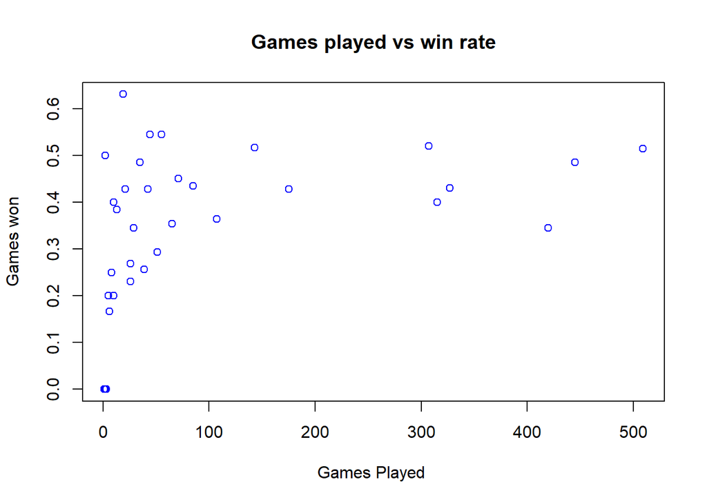

```r
#scalter plot

plot(golietable15$gamesPlayed, golietable15$wins/golietable15$gamesPlayed , col="blue",
     xlab="Games Played ",
     ylab = "Games won",
     main = "Games played vs win rate")
```

The active players has larger width, which can be the effect of very lower number of players .

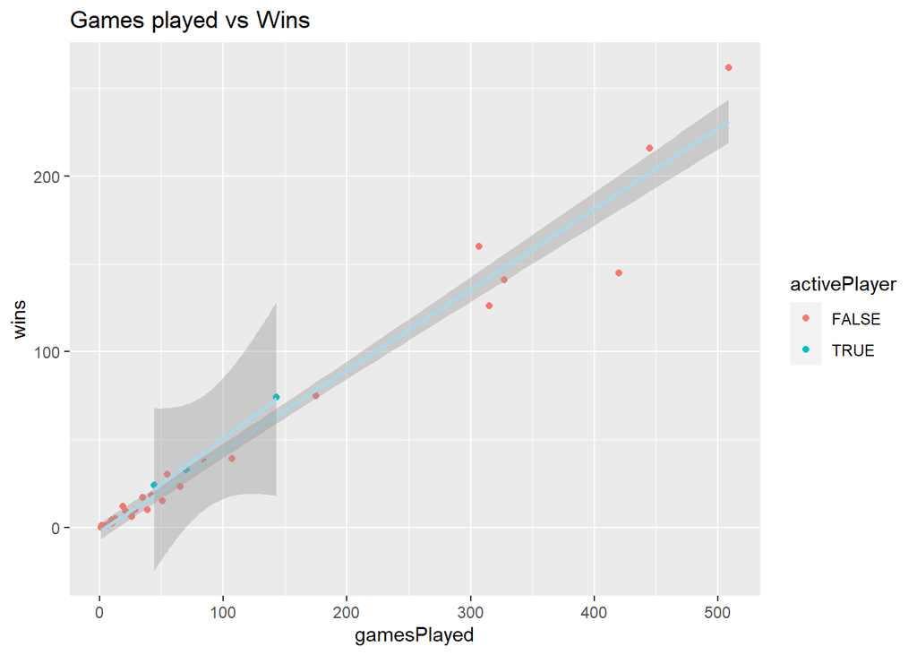

```r
ggplot (golietable15, aes(x=gamesPlayed, y=wins, group=activePlayer)) + geom_point(aes(color= activePlayer)) + geom_smooth(method='lm', color='light blue') + ggtitle("Games played vs Wins")
```

##### Box plot

The players not tagged as active players looks to have loose the higest number of games. But in the median number of games lost is higher for active players.

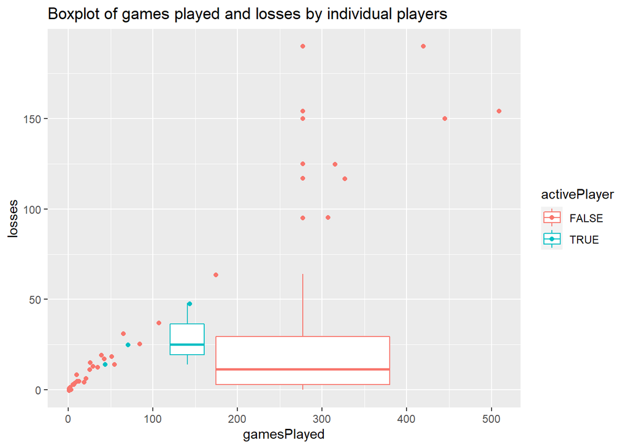

```r
#box plot
bxPlot1<- ggplot(data= golietable15, aes(x=gamesPlayed, y= losses, group=activePlayer, color=activePlayer))
bxPlot1 + geom_boxplot() + labs(title="Boxplot of games played and losses by individual players") + geom_jitter(aes(color=activePlayer))
```

##### Bar plots

Again, there are very few, less than 5 players are categorized as active player, which seems unreal.

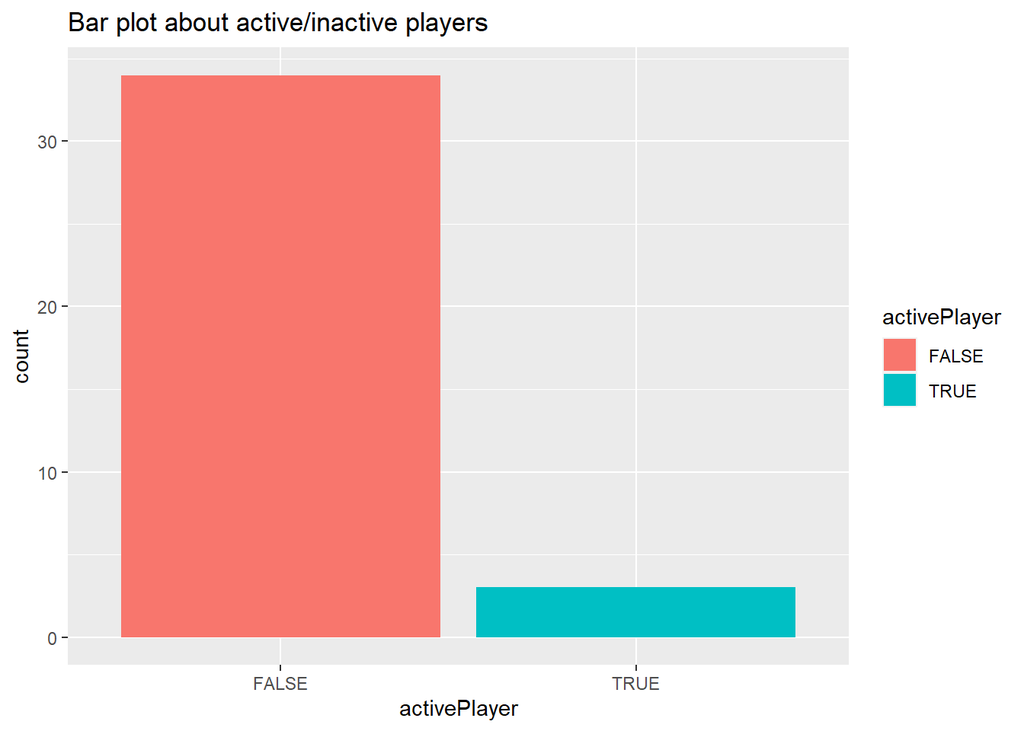

```r
type2<-  golietable15 %>% select(playerName, gamesPlayed, wins, activePlayer, gameTypeId)
barPlot1<- ggplot(data=type2, aes(x=activePlayer))
barPlot1 + geom_bar(aes(fill= activePlayer), position = "dodge") + labs(title = "Bar plot about active/inactive players")
```

##### Histogram

The histogram for games played grahp shows that there are very few players playing the regular season who are tagged as active player. They seem to be played between 40 to 150 games throught their entire career for the data collected period. Also, it shwos there are large group of players who played less than 5 games.

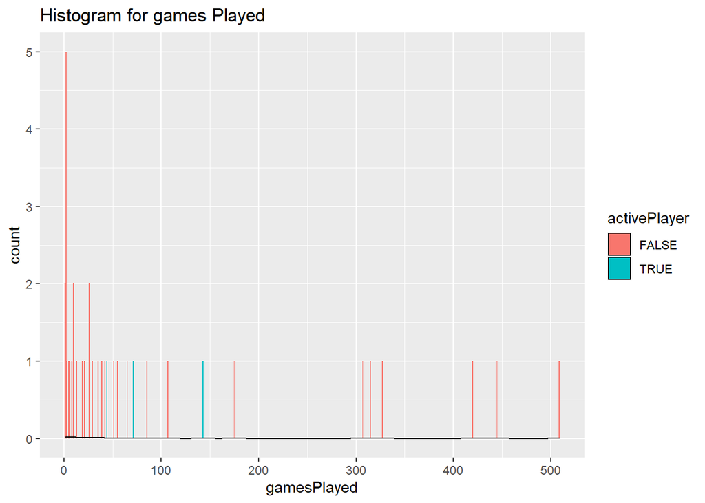

```r
type3<- golietable15 %>% select(wins, losses, activePlayer, gamesPlayed) #(gameTypeId==3,
histogram1<- ggplot(data=type3, aes(x=gamesPlayed))
histogram1 + geom_histogram(binwidth = 1, aes(fill= activePlayer)) + labs(title="Histogram for games Played") +
  geom_density(adjust= 0.25, alpha=0.05)
```

The histogram looks extremly right skewed that the players playing higher number of games are lesser

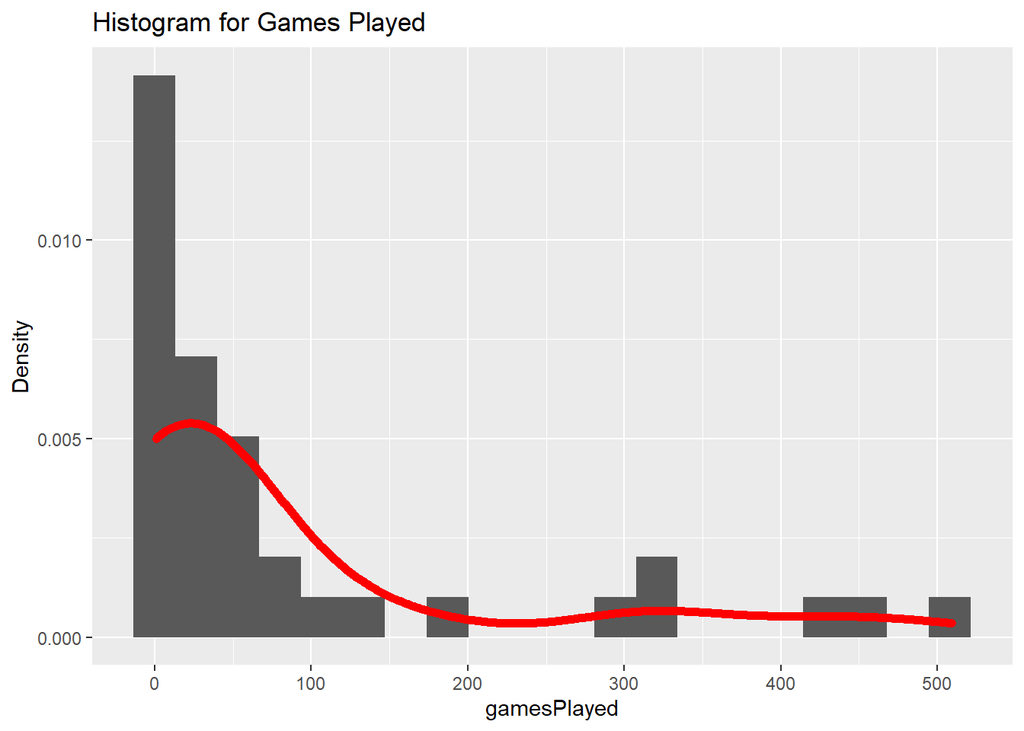

```r
ggplot(golietable15, aes(x=gamesPlayed, ..density..)) + geom_histogram(bins=20) + ggtitle("Histogram for Games Played") + ylab("Density") + geom_density(col="red", lwd=2, adjust=2)
```

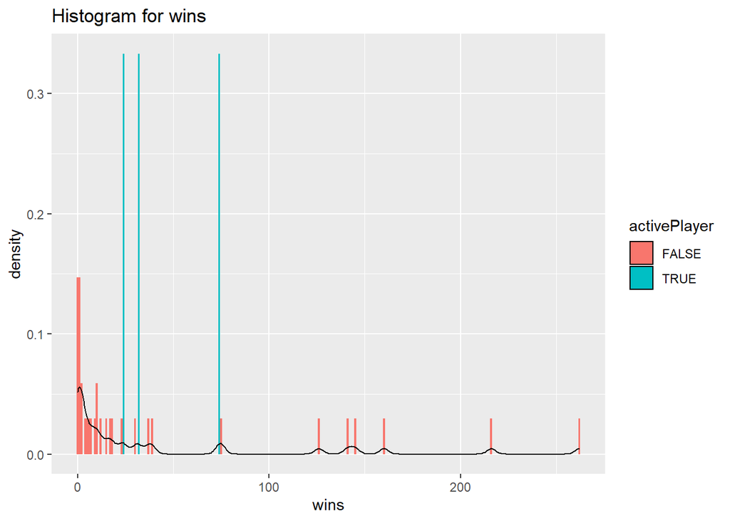

```r
type3<- golietable15 %>% select(wins, losses, activePlayer, gamesPlayed, playerId) #(gameTypeId==3, division.name=="Atlantic")
histogram1<- ggplot(data=type3, aes(x=wins))
histogram1 + geom_histogram(binwidth = 1, aes(y=..density.., fill= activePlayer )) + labs(title="Histogram for wins") +  geom_density(adjust= 0.2, alpha=0.05)
```

For the shake of try, the above histograms does not look preety well distributed data, so I tried below to see it on win rates, a calculated variable. The win rate is left skewed.

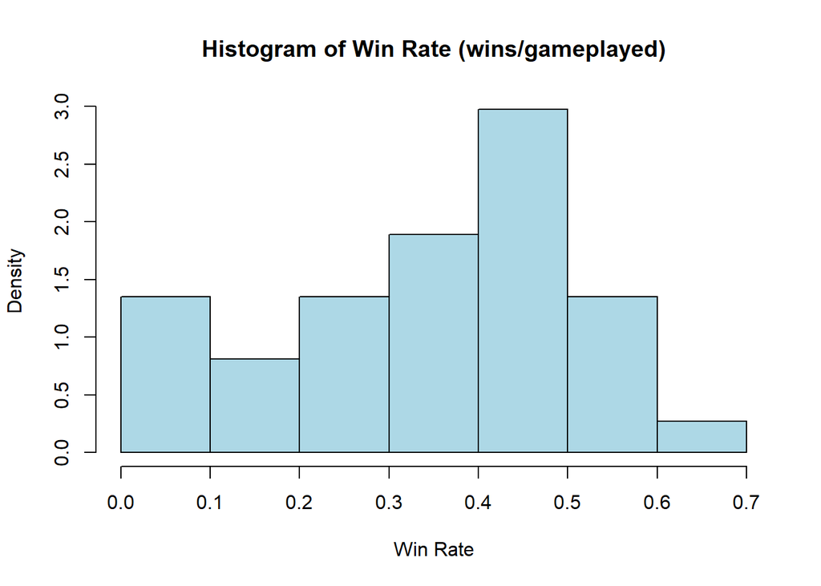

```r
hist(wlRate$winRate, probability = T, col = "light blue", xlab = "Win Rate", main = "Histogram of Win Rate (wins/gameplayed)")
```

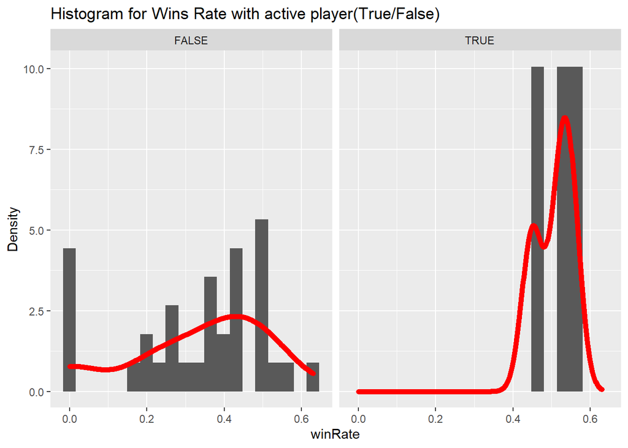

```r
ggplot (wlRate, aes(x=winRate, ..density..)) + geom_histogram(bins=20) + facet_wrap(golietable15$activePlayer) + ggtitle("Histogram for Wins Rate with active player(True/False)") + ylab("Density") + geom_density(col="red", lwd=2, adjust=1)
```